# Análise de Regressão na Produtividade de Soja

Arthur Hintz

11 jul 2024

# Resumo

O trabalho tem como objetivo realizar uma análise de regressão linear múltipla para estimar a produtividade de soja em (Kg/ha) com base nos principais fatores que a influenciam. A análise será dividida em quatro etapas principais: análise descritiva, ajuste do modelo, diagnóstico de influência e teste das suposições do modelo.

# Introdução

Segundo a Confederação da Agricultura e Pecuária do Brasil (CNA), o Produto Interno Bruto (PIB) do Agronegócio corresponde a 23,8% em 2023, sendo a soja a commodity de maior valor de produção no Brasil, de acordo com dados divulgados pelo IBGE, [link de acesso](https://www.ibge.gov.br/explica/producao-agropecuaria/). Na produção de soja, muitos fatores influenciam o resultado, sendo vários deles incontroláveis, como fatores climáticos. Este ano, por exemplo, houve um aumento de 70,83% na produtividade em relação ao ano anterior, provavelmente relacionado ao volume de precipitação.

Dessa forma, torna-se necessário estimar a produtividade da soja e verificar quais são as principais variáveis que a influenciam, permitindo realizar predições da safra e estimar o potencial de produção a nível nacional.

Inicialmente, será realizada uma análise descritiva dos dados para compreender as variáveis envolvidas e suas inter-relações. Em seguida, o modelo de regressão linear múltipla será ajustado para identificar os fatores mais significativos que afetam a produtividade da soja. O diagnóstico de influência ajudará a identificar pontos de dados que têm um impacto desproporcional no ajuste do modelo, possibilitando a correção ou análise adicional desses pontos. Finalmente, as suposições do modelo de regressão linear serão testadas para garantir a validade das conclusões obtidas.

Os dados utilizados neste estudo foram disponibilizados pela empresa Crops Team e foram coletados a partir de experimentos com cultivares de soja realizados em diversos locais do estado do Rio Grande do Sul durante as safras de 2021/2022 e 2022/2023.

Este estudo é importante porque permite identificar os principais determinantes da produtividade da soja, fornecendo insights valiosos para a tomada de decisões agrícolas e a otimização dos rendimentos das cultivares. Ao compreender melhor os fatores que influenciam a produtividade, produtores e pesquisadores podem implementar práticas agrícolas mais eficazes.

# Dados

O banco de dados, inicialmente, continha informações dos 4 blocos de ensaios para cada cultivar. Posteriormente, foi calculada a média dos blocos por cultivar, resultando em 1513 observações e 33 variáveis. Entretanto, após o precesso de filtragens e tratamento de valores faltantes, esses números foram reduzidos. As variáveis do banco de dados incluem informações sobre as cultivares, características do local, dados climáticos durante o período dos experimentos e componentes químicos do solo.

- **Cultivares:** Informações sobre as diferentes variedades de soja utilizadas nos experimentos.
- **Localização:** Características geográficas dos locais onde os experimentos foram conduzidos.
- **Dados Climáticos:** Informações sobre precipitação, temperatura e outras condições climáticas durante o período dos experimentos.
- **Componentes Químicos do Solo:** Dados sobre a composição química do solo, incluindo níveis de nutrientes e pH.

Dentre essas principais características, as variáveis mais significativas utilizadas no modelo foram:

1. `Terras`: divididas em (Altas ou Baixas)
2. `Ambiente`: dividido em (Sequeiro ou Irrigado)
3. `Cultura_Ant`: (“arroz e pousio”,“aveia”, “aveia branca”, “aveia e centeio”, “aveia e ervilhaca”, “azevem”, “cevada”, nabo”)
4. `P_base`: Quantidade de adubação de Fósforo
5. `N_base`: Quantidade de adubação de Nitrogênio
6. `Produtividade`: Produtividade de soja (Kg/ha)
7. `GMR`: Grupo de maturação relativo
8. `Espacamento`: Espaçamento entre linhas do plantio de soja
9. `Temperatura_Max`: média da temperatura máxima durante o périodo
10. `PH`: PH do solo
11. `M.O.(%)`: Matéria orgânica (%)
12. `Epoca_de_semeadura`: Data de plantio

Sendo as primeiras colunas e observações dadas por:

| X | Safra | COD_PROD | Local | Cod_Estacao_Met | Altitude | Terras | Ambiente | Cultivar | Cultura_Ant | Epoca_de_semeadura | N_base |
| --- | --- | --- | --- | --- | --- | --- | --- | --- | --- | --- | --- |
| 390 | 2021/2022 | AG117 | ALEGRETE | A826 | 117 | BAIXAS | SEQUEIRO | AS 3595 I2X | azevem | 2021-11-23 | 13.5 |
| 391 | 2021/2022 | AG117 | ALEGRETE | A826 | 117 | BAIXAS | SEQUEIRO | AS 3615 I2X | azevem | 2021-11-23 | 13.5 |
| 392 | 2021/2022 | AG117 | ALEGRETE | A826 | 117 | BAIXAS | SEQUEIRO | BMX COMPACTA IPRO | azevem | 2021-11-23 | 13.5 |
| 393 | 2021/2022 | AG117 | ALEGRETE | A826 | 117 | BAIXAS | SEQUEIRO | BMX CROMO TF IPRO | azevem | 2021-11-23 | 13.5 |
| 394 | 2021/2022 | AG117 | ALEGRETE | A826 | 117 | BAIXAS | SEQUEIRO | BMX LOTUS IPRO | azevem | 2021-11-23 | 13.5 |

# Análise Descritiva

As análises dos dados referem-se a um processo crítico em relação produtividade de soja no RS. Dessa forma, foi verificado medidas de tendência central, medidas de disperção, as relações entre as variáveis e suas distribuições.

Data summary

| Name | dados |
| --- | --- |
| Number of rows | 1513 |
| Number of columns | 33 |
| _______________________ |  |
| Column type frequency: |  |
| character | 10 |
| numeric | 22 |
| POSIXct | 1 |
| ________________________ |  |
| Group variables | None |

**Variable type: character**

| skim_variable | n_missing | min | max | empty | n_unique | whitespace |
| --- | --- | --- | --- | --- | --- | --- |
| X | 0 | 3 | 4 | 0 | 1513 | 0 |
| Safra | 0 | 9 | 9 | 0 | 2 | 0 |
| COD_PROD | 0 | 5 | 5 | 0 | 34 | 0 |
| Local | 0 | 5 | 23 | 0 | 27 | 0 |
| Cod_Estacao_Met | 0 | 4 | 4 | 0 | 18 | 0 |
| Terras | 0 | 5 | 6 | 0 | 2 | 0 |
| Ambiente | 0 | 8 | 8 | 0 | 3 | 0 |
| Cultivar | 0 | 5 | 25 | 0 | 184 | 0 |
| Cultura_Ant | 0 | 2 | 17 | 0 | 13 | 0 |
| PRODUTOR/PARCEIRO | 0 | 3 | 26 | 0 | 32 | 0 |

**Variable type: numeric**

| skim_variable | n_missing | mean | sd | p0 | p25 | p50 | p75 | p100 |
| --- | --- | --- | --- | --- | --- | --- | --- | --- |
| Altitude | 0 | 304.69 | 217.97 | 3.00 | 105.00 | 288.00 | 489.00 | 688.00 |
| N_base | 191 | 12.46 | 8.56 | 0.00 | 6.00 | 9.20 | 17.20 | 40.00 |
| P_base | 191 | 74.45 | 28.20 | 40.00 | 56.00 | 64.40 | 92.00 | 135.00 |
| K_base | 191 | 41.47 | 32.79 | 0.00 | 0.00 | 45.50 | 60.00 | 112.50 |
| Produtividade | 0 | 2630.00 | 1417.06 | 185.00 | 1512.70 | 2416.70 | 3622.57 | 6898.68 |
| GMR | 32 | 5.83 | 0.43 | 4.90 | 5.50 | 5.80 | 6.10 | 8.10 |
| N_Plantas | 474 | 77.28 | 25.36 | 12.00 | 59.75 | 74.50 | 92.25 | 172.00 |
| Espacamento | 53 | 0.47 | 0.04 | 0.40 | 0.45 | 0.45 | 0.45 | 0.58 |
| Area_colhida | 247 | 3.37 | 0.96 | 0.90 | 2.70 | 3.60 | 4.05 | 5.40 |
| Populacao | 247 | 18.12 | 9.21 | 0.00 | 15.25 | 20.30 | 24.07 | 43.98 |
| Temperatura_Max | 0 | 24.42 | 1.23 | 22.08 | 23.59 | 24.48 | 25.08 | 28.10 |
| Precipitacao_Total | 0 | 389.34 | 88.58 | 158.70 | 315.90 | 372.80 | 451.20 | 735.20 |
| Umidade_Med | 0 | 68.61 | 6.20 | 52.93 | 64.45 | 68.68 | 72.00 | 80.19 |
| Radiacao_Med | 0 | 24285.63 | 2940.83 | 20411.79 | 22770.84 | 23768.85 | 24520.27 | 38592.57 |
| PH | 0 | 5.18 | 0.35 | 4.50 | 5.00 | 5.10 | 5.30 | 6.30 |
| ARGILA | 18 | 43.19 | 20.31 | 4.00 | 27.00 | 44.00 | 59.00 | 85.00 |
| P(mg/L) | 0 | 26.14 | 41.91 | 2.50 | 9.00 | 19.00 | 27.00 | 359.20 |
| K(mg/L) | 0 | 130.42 | 109.59 | 28.00 | 72.00 | 88.00 | 180.00 | 636.00 |
| M.O.(%) | 0 | 2.51 | 0.83 | 1.00 | 1.90 | 2.50 | 2.90 | 5.90 |
| CTC PH7 | 0 | 14.09 | 4.21 | 6.90 | 11.40 | 14.00 | 15.40 | 35.50 |
| SATURACAO DE BASE(%) | 0 | 62.70 | 14.10 | 27.00 | 54.00 | 65.00 | 76.00 | 86.00 |
| SATURACAO Al(%) | 0 | 3.38 | 5.74 | 0.00 | 0.00 | 2.10 | 4.00 | 34.00 |

**Variable type: POSIXct**

| skim_variable | n_missing | min | max | median | n_unique |
| --- | --- | --- | --- | --- | --- |
| Epoca_de_semeadura | 0 | 2021-09-16 | 2022-12-14 | 2022-11-06 | 40 |

Podemos verificar valores faltantes em algumas variáveis no banco de dados, dessa forma, foram retiradas essas observações devido a falta de informação para o preenchimento correto desses NA’s. Além disso, podemos ter uma ideia da média e da distribuição dos dados

Com o gráfico a seguir, podemos verificar as principais correlações entre as variáveis numéricas e já procurar possiveis casos de multicolinearidade e variáveis que podem ser mais significativas para estimar a produtividade de soja

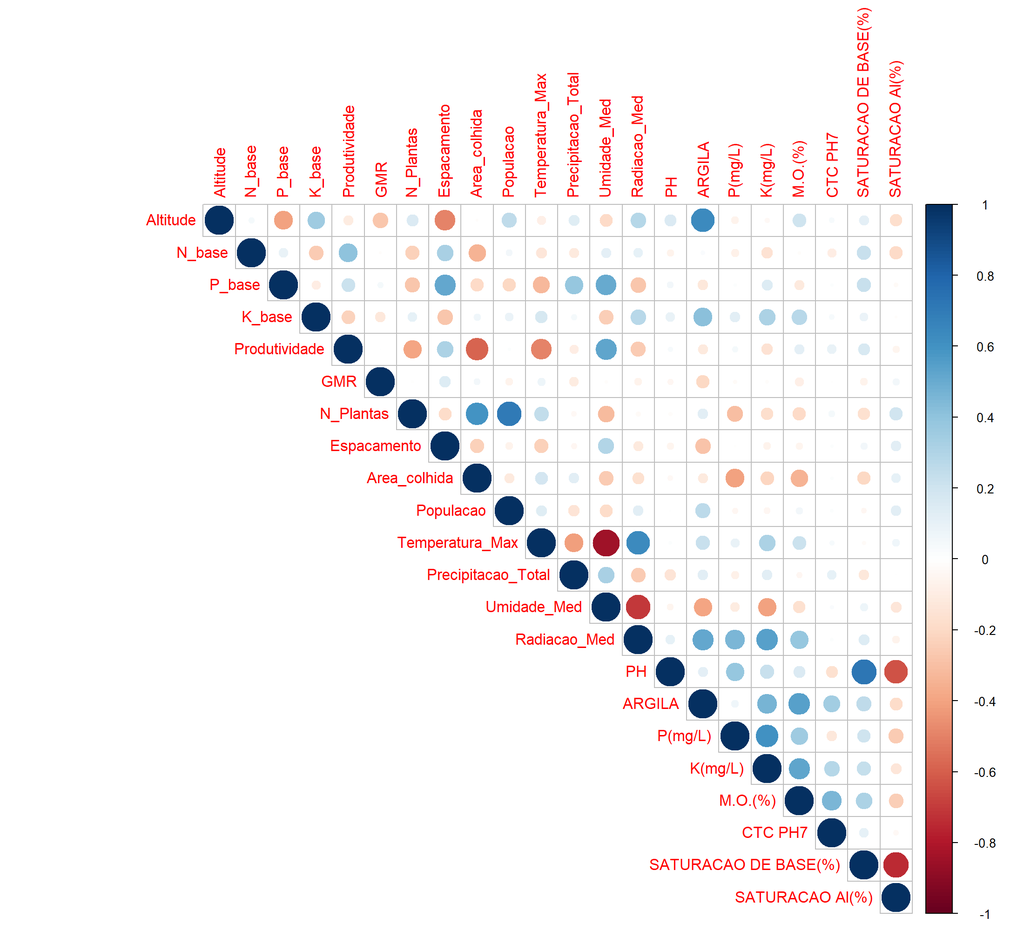

O gráfico de correlação entre as variáveis pode ser interpretado a partir do tamanho dos círculos e da cor. Quanto maior o círculo e mais escura é a cor mais forte é a correlação, também, se puxar mais para o azul é positiva, se for vermelha é negativa.

Principais medidas da variável de interesse e um gráfico para mostrar frequência de produtividade

**Média da produtividade:** 2458

**Desvio padrão da produtividade:** 1434

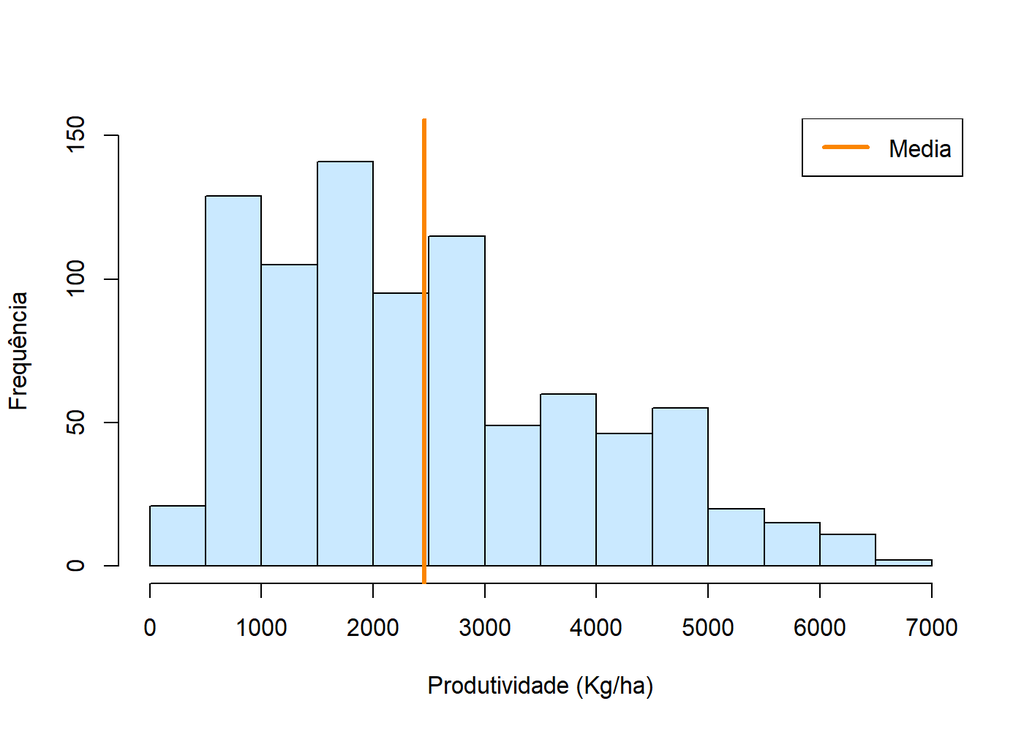

O gráfico de boxplot mostra a relação entre os anos das safras com a produtividade

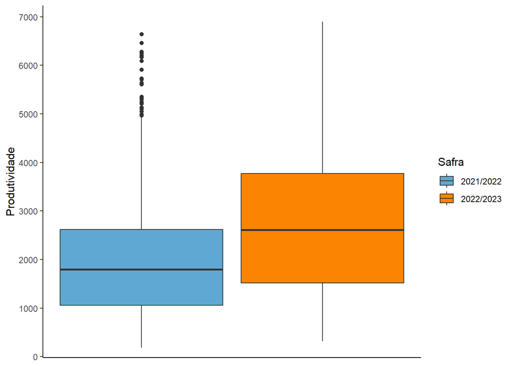

Nota-se um diferença de produtividade entre as duas safras, de certa forma a variável `Safra` deveria ser significativa para a explicação da produtividade de soja, no entanto ja tem relação com outras variáveis do modelo. Além disso, deve explicar a alta variabilidade dos erros, conforme será apresentado nas suposições do modelo.

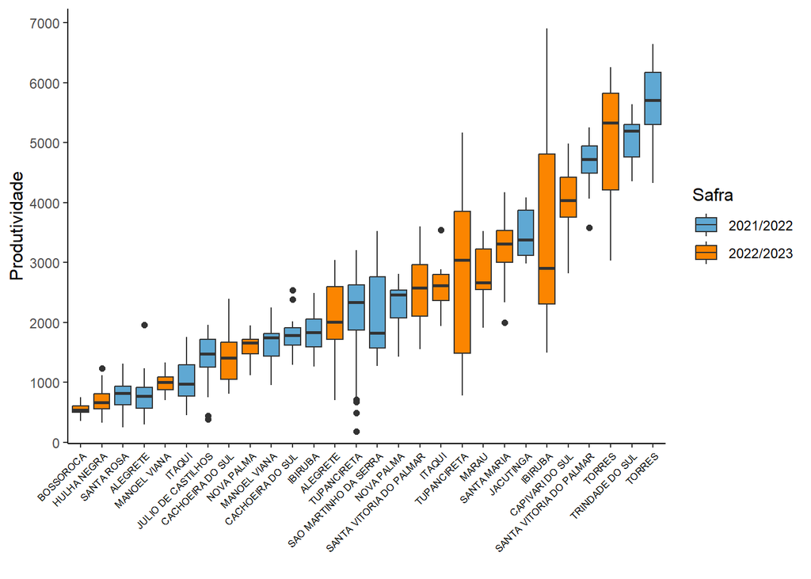

A partir do gráfico percebe-se a alta variabilidade de produtividade entre os locais de ensaio nas duas safras.

# Ajustes dos Dados

1 - Inicialmente foi removida uma cultivar experimental e cultivares com grupos de maturação relativos maiores que 7

2 - Os locais Santa Rosa e Jacutinga apresentaram ser pontos influêntes para o modelo. Logo para o ajuste foi melhor remover essas observações

3 - Locais os quais não tiveram uma cultura antes do plantio de soja ou tiveram mix também foram pontos de alavancagem para o modelo.

4 - Criação da variável `mês`, relacionada a data de plantio, ou seja, invés de ter dia e mês, tem se apenas o mês

5 - Foi alterado a variável `Terras`, em que Baixas recebe 0 e Altas recebe 1. A variável `Ambiente`, “irrigado” = 1 e “sequeiro” = 0

Os dados depois de filtrados e selecionados as variáveis importantes para o modelo, é dado por:

| Terras | Ambiente | Cultura_Ant | P_base | N_base | Produtividade | GMR | Espacamento | Temperatura_Max | PH | M.O.(%) | mes |
| --- | --- | --- | --- | --- | --- | --- | --- | --- | --- | --- | --- |
| 0 | 1 | azevem | 135.0 | 9.0 | 4330.1250 | 6.1 | 0.50 | 23.26305 | 4.9 | 2.0 | nov |
| 1 | 0 | aveia | 69.0 | 6.0 | 2585.2788 | 5.8 | 0.45 | 24.59763 | 5.0 | 2.6 | nov |
| 1 | 1 | aveia | 43.0 | 17.2 | 4275.1000 | 5.4 | 0.45 | 24.76108 | 4.9 | 3.0 | out |
| 0 | 0 | azevem | 69.0 | 13.5 | 405.2235 | 5.7 | 0.45 | 25.07801 | 4.8 | 1.2 | nov |
| 1 | 1 | trigo | 40.0 | 16.0 | 3592.3250 | 5.8 | 0.45 | 25.35516 | 5.1 | 2.9 | nov |
| 1 | 0 | trigo | 40.0 | 16.0 | 906.2000 | 5.4 | 0.45 | 25.35516 | 5.1 | 2.9 | nov |
| 1 | 1 | aveia e ervilhaca | 57.5 | 5.0 | 2897.3250 | 6.4 | 0.45 | 24.47887 | 6.3 | 2.8 | out |
| 1 | 1 | aveia e ervilhaca | 57.5 | 5.0 | 2735.3250 | 5.9 | 0.45 | 24.47887 | 6.3 | 2.8 | out |
| 1 | 1 | aveia e ervilhaca | 57.5 | 5.0 | 1058.9250 | 4.9 | 0.45 | 23.69126 | 4.8 | 2.7 | nov |
| 0 | 0 | azevem | 56.0 | 6.0 | 3135.2500 | 5.2 | 0.45 | 23.68543 | 5.3 | 2.0 | dez |

# Modelo Ajustado

Inicialmente, foi selecionada as variáveis do modelo pelo algoritmo de Stepwise, determinando aquele com menor AIC

|  | Estimate | Std. Error | t value | Pr(>\|t\|) |
| --- | --- | --- | --- | --- |
| (Intercept) | 34062.508754 | 908.227227 | 37.5043907 | 0.0000000 |
| Terras1 | -1494.382152 | 81.064383 | -18.4345098 | 0.0000000 |
| Ambiente0 | -2410.469323 | 60.900930 | -39.5801725 | 0.0000000 |
| Cultura_Antaveia | -222.616571 | 127.881313 | -1.7408061 | 0.0821773 |
| Cultura_Antaveia e centeio | -1633.721856 | 159.065955 | -10.2707198 | 0.0000000 |
| Cultura_Antaveia e ervilhaca | -3278.926009 | 145.752264 | -22.4965700 | 0.0000000 |
| Cultura_Antazevem | -1333.979455 | 99.802047 | -13.3662534 | 0.0000000 |
| Cultura_Antcevada | -314.252257 | 145.808254 | -2.1552433 | 0.0314989 |
| Cultura_Antnabo | -2098.207963 | 173.752054 | -12.0758743 | 0.0000000 |
| Cultura_Anttrigo | -74.332602 | 115.227491 | -0.6450943 | 0.5190872 |
| P_base | 5.817805 | 1.336358 | 4.3534770 | 0.0000155 |
| N_base | -36.833253 | 3.803653 | -9.6836523 | 0.0000000 |
| GMR | 177.136001 | 43.457706 | 4.0760551 | 0.0000513 |
| Espacamento | -13410.385353 | 969.980868 | -13.8254122 | 0.0000000 |
| Temperatura_Max | -1080.879735 | 29.997418 | -36.0324257 | 0.0000000 |
| PH | 589.197131 | 73.340645 | 8.0337053 | 0.0000000 |
| `M.O.(%)` | 477.670294 | 33.857294 | 14.1083424 | 0.0000000 |
| mesnov | -646.319615 | 77.359217 | -8.3547848 | 0.0000000 |
| mesout | -486.693245 | 74.382306 | -6.5431319 | 0.0000000 |

O Modelo de regresssão linear múltipla, é expressado pela equação:

$$Y= \beta_0 + \sum^{18}_{i=1} \beta_i
X_{i} + \epsilon$$

Sendo:

$Y = 34062.5 -1494.4 X_{1} -2410.5 X_{2} -222.6 X_{3} -1633.7 X_{4} -3278.9 X_{5} -1334 X_{6} -314.3 X_{7} \\ -2098.2 X_{8} -74.3 X_{9} + 5.8 X_{10} -36.8 X_{11} + 177.1 X_{12} -13410.4 X_{13} \\ -1080.9 X_{14} + 589.2 X_{15} + 477.7 X_{16} -646.3 X_{17} -486.7 X_{18} + \epsilon$

Em que:

$X_1$ = Terras, $x \in \{0, 1\}$

$X_2$ = Ambiente, $x \in \{0, 1\}$

$X_3$ = Aveia, $x \in \{0, 1\}$

$X_4$ = Aveia e centeio, $x \in \{0, 1\}$

$X_5$ = Aveia e ervilhaca, $x \in \{0, 1\}$

$X_6$ = Azevém, $x \in \{0, 1\}$

$X_7$ = Cevada, $x \in \{0, 1\}$

$X_8$ = Nabo, $x \in \{0, 1\}$

$X_9$ = Trigo, $x \in \{0, 1\}$

$X_{10}$ = P_base, $x \in [40, 135]$

$X_{11}$ = N_base, $x \in [5, 40]$

$X_{12}$ = GMR, $x \in [4.9, 6.7]$

$X_{13}$ = Espacamento, $x \in [0.4, 0.575]$

$X_{14}$ = Temperatura_Max, $x \in [22.32, 27.07]$

$X_{15}$ = PH, $x \in [4.8, 6.3]$

$X_{16}$ = M.O.(%), $x \in [1, 4.2]$

$X_{17}$ = Novembro, $x \in \{0, 1\}$

**Interpretação dos betas:**

- $\beta_1$, significa que terras altas produzem -1494.4 kg/ha a menos que terras baixas.
- $\beta_2$, significa que ambientes sequeiros produzem -2410.5 kg/ha a menos que ambientes irrigados
- $\beta_{3}, \cdots, \beta_9$ , quanto maior o beta maior é significante para o aumento de produtividade, ou seja, neste caso o plantio de trigo antes da soja melhora a protuvidade.
- $\beta_{10}$, a cada um 1 kg/ha de fósforo, dentro do intervalo de $X_{10}$ estabelecido, aumenta 5.8 kg/ha na produtividade de soja.
- $\beta_{11}$ a cada um 1 kg/ha de nitrogênio, dentro do intervalo de $X_{11}$ estabelecido, diminui -36.8 kg/ha na produtividade de soja.
- $\beta_{12}$, quanto maior for o GMR, maior será a produtividade
- $\beta_{13}$, espaçamentos menores tem mais incremento na produtividade
- $\beta_{14}$, temperaturas mais altas diminuem a produtividade.
- $\beta_{15}$, o PH do solo tem um fator positivo na produtividade
- $\beta_{16}$, a cada um 1% de matéria orgânica, aumenta em 477.7 kg/ha de soja
- $\beta_{17}$ e $\beta_{18}$, o plantio no mês de outubro em relação ao mês de novembro tem um acréscimo de aproximadamente 160 kg/ha.

O coeficiente de determinação, $R^2$, é dado por 0.9106993, ou seja, significa que 91.1% da variabilidade na produtividade da soja pode ser explicada pelas variáveis incluídas no modelo de regressão.

# Analise de diagnóstico

As principais observações influentes podem ser visualizadas na tabela a seguir

| Terras | Ambiente | Cultura_Ant | P_base | N_base | Produtividade | GMR | Espacamento | Temperatura_Max | PH | M.O.(%) | mes |
| --- | --- | --- | --- | --- | --- | --- | --- | --- | --- | --- | --- |
| 0 | 1 | azevem | 135.0 | 9.0 | 4330.125 | 6.1 | 0.50 | 23.26305 | 4.9 | 2.0 | nov |
| 1 | 1 | aveia e ervilhaca | 57.5 | 5.0 | 1058.925 | 4.9 | 0.45 | 23.69126 | 4.8 | 2.7 | nov |
| 1 | 0 | aveia e centeio | 90.0 | 6.0 | 868.800 | 5.8 | 0.45 | 23.95177 | 4.9 | 1.4 | nov |
| 1 | 0 | azevem | 54.6 | 7.8 | 1907.925 | 5.2 | 0.45 | 22.68672 | 5.4 | 2.5 | nov |
| 1 | 0 | aveia e centeio | 90.0 | 6.0 | 750.800 | 5.3 | 0.45 | 23.95177 | 4.9 | 1.4 | nov |
| 1 | 0 | aveia e centeio | 90.0 | 6.0 | 694.150 | 5.0 | 0.45 | 23.95177 | 4.9 | 1.4 | nov |
| 1 | 0 | aveia e centeio | 90.0 | 6.0 | 1058.175 | 6.4 | 0.45 | 23.95177 | 4.9 | 1.4 | nov |
| 1 | 0 | aveia e centeio | 90.0 | 6.0 | 957.900 | 6.0 | 0.45 | 23.95177 | 4.9 | 1.4 | nov |

Apesar de ainda possuir pontos de influência não afetam no ajuste do modelo

## Alavancagem

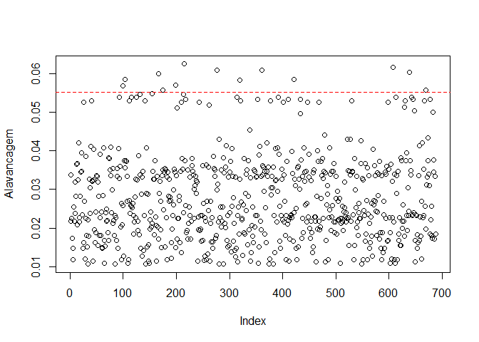

Como de esperado ficou alguns pontos de alavancagem, mas a retirada deles não afetaram o $R^2$ do modelo

## DFFIT

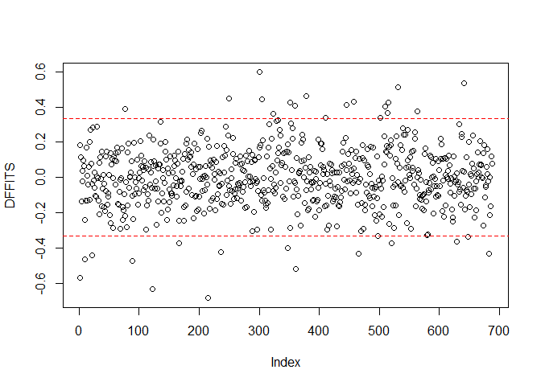

É possível observar que alguns pontos têm valores dos DFFITS acima da linha de referência, mas após análises, eles não apresentaram influência na regressão

## Distância de Cook

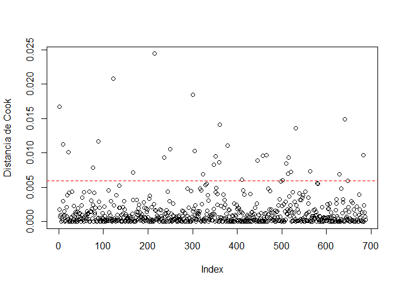

Os mesmos pontos identificados anteriormente aparece no gráfico da distância de cook, mas a remoção dos mesmos não afeta significativamente nos coeficientes da regressão.

## Resíduo

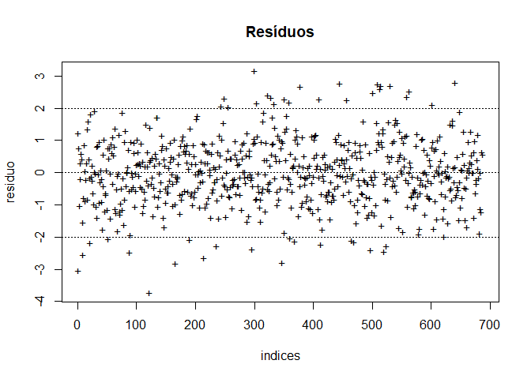

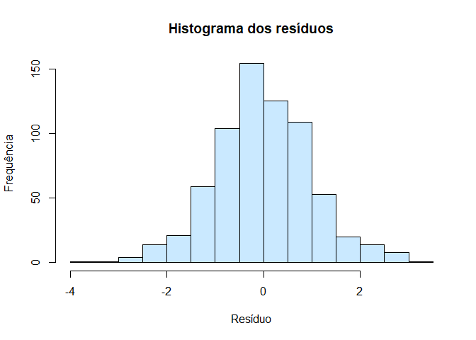

Como esperado, a distribuição dos resíduos tende a se aproximar de uma distribuição normal com média 0. Esta suposição será verificada a seguir através de testes de normalidade.

## Envelope Simulado

Baseado nos resíduos studentizados para verificação de normalidade

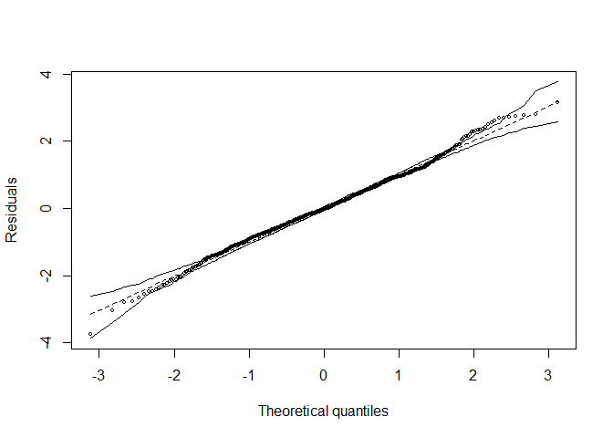

A partir do gráfico podemos ver alguns pontos fora do intervalo, mas como n = 688, é esperado a 5% que até 34.4 pontos fiquem fora do intervale e após testes os resíduos seguem normalidade conforme é esperado.

# Suposições do modelo

- [S0] O modelo esta corretamente específicado
- [S1] A média dos erros é zero
- [S2] Homoscedasticidade dos erros
- [S3] Não autocorrelacão
- [S4] Ausência de Multicolinearidade
- [S5] Normalidade dos erros

## Teste RESET

$$\begin{cases}
H_0: \textrm{O modelo esta corretamente especificado}\\
H_1: \textrm{O modelo não esta corretamente especificado}.
\end{cases}$$

```
##
##  RESET test
##
## data:  fit
## RESET = 3.8991, df1 = 2, df2 = 667, p-value = 0.02072
```

Conforme o tese RESET, utilizado para verificar se o modelo está corretamente específicado, não rejeita-se $H_0$ devido p-valor = 0.0207244 > $\alpha$ = 0.01, ou seja, O modelo esta corretamente especificado.

## Teste t para a média dos errros

$$\begin{cases}
H_0: \textrm{ A média dos erros é igual a zero
}\\
H_1: \textrm{média dos erros é diferente de zero}.
\end{cases}$$

```
##
##  One Sample t-test
##
## data:  resid(fit)
## t = -1.9068e-15, df = 687, p-value = 1
## alternative hypothesis: true mean is not equal to 0
## 95 percent confidence interval:
##  -31.82613  31.82613
## sample estimates:
##     mean of x
## -3.090807e-14
```

Conforme o teste T de Student, não rejeita-se $H_0$ devido ao p-valor = 1 > $\alpha$ = 0.01. Dessa forma, a média dos erros é igual a zero.

## Teste de Bressch-Pagan

$$\begin{cases}
H_0: \textrm{ Os erros são homoscedasticos
}\\
H_1: \textrm{Os erros não são homoscedasticos}.
\end{cases}$$

```
##
##  studentized Breusch-Pagan test
##
## data:  fit
## BP = 100.22, df = 18, p-value = 2.016e-13
```

Conforme o teste de Breusch-Pagan, rejeita-se $H_0$ devido p-valor = 2.0160966^{-13} < $\alpha$ = 0.01. Dessa forma, os erros são heteroscedasticos, não seguindo a suposição $[S2]$. O ideal para seria modelar a variância junto, já que existe muita diferença de manejo dos produtores entre os locais dos experimentos.

## Teste de Durbin-Watson

$$\begin{cases}
H_0: \textrm{Não há autocorrelação}\\
H_1: \textrm{Há autocorrelação}.
\end{cases}$$

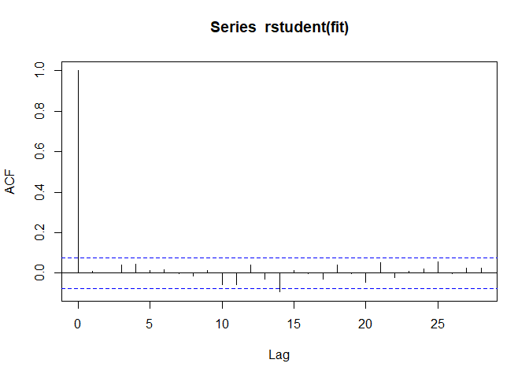

```
##
##  Durbin-Watson test
##
## data:  fit
## DW = 1.9708, p-value = 0.347
## alternative hypothesis: true autocorrelation is greater than 0
```

## Fatores de Inflação de Variância

$$\begin{cases}
H_0: \textrm{Não há multicolinearidade}\\
H_1: \textrm{Há multicolinearidade}.
\end{cases}$$

|  | GVIF | Df | GVIF^(1/(2*Df)) |
| --- | --- | --- | --- |
| Terras | 5.036604 | 1 | 2.244238 |
| Ambiente | 3.174420 | 1 | 1.781690 |
| Cultura_Ant | 54.890862 | 7 | 1.331220 |
| P_base | 2.649398 | 1 | 1.627697 |
| N_base | 3.077642 | 1 | 1.754321 |
| GMR | 1.113293 | 1 | 1.055127 |
| Espacamento | 2.360238 | 1 | 1.536307 |
| Temperatura_Max | 3.029015 | 1 | 1.740407 |
| PH | 2.649733 | 1 | 1.627800 |
| `M.O.(%)` | 2.279752 | 1 | 1.509885 |
| mes | 6.295974 | 2 | 1.584038 |

Interpretação:

vif maior que 10 indica multicolinearidade, vif próximo de 1 seria o ideal.

## Teste Jarque-Bera

$$\begin{cases}
H_0: \textrm{Os erros possuem distribuição normal}\\
H_1: \textrm{Os erros não possuem distribuição normal}.
\end{cases}$$

```
##
##  Jarque Bera Test
##
## data:  resid(fit)
## X-squared = 7.3333, df = 2, p-value = 0.02556
```

Conforme o teste de Jarque-Bera, não rejeita-se $H_0$ devido ao p-valor = 0.0255623$ > = 0.01$. Ou seja, os erros possuem distribuição normal

# Predição

Novos Dados e Predição

| Terras | Ambiente | Cultura_Ant | P_base | N_base | GMR | Espacamento | Temperatura_Max | PH | M.O.(%) | mes | Predicao |
| --- | --- | --- | --- | --- | --- | --- | --- | --- | --- | --- | --- |
| 1 | 0 | aveia | 70 | 10 | 5.0 | 0.50 | 25 | 5 | 2 | nov | 387.4551 |
| 1 | 1 | cevada | 80 | 6 | 6.0 | 0.45 | 26 | 7 | 3 | out | 4494.2662 |
| 0 | 0 | aveia e ervilhaca | 75 | 7 | 5.5 | 0.45 | 26 | 8 | 4 | dez | 2012.5757 |

O gráfivo a seguir mostra a relação entre os valores reais de produtividade, com os valores preditos a partir do modelo de regressão.

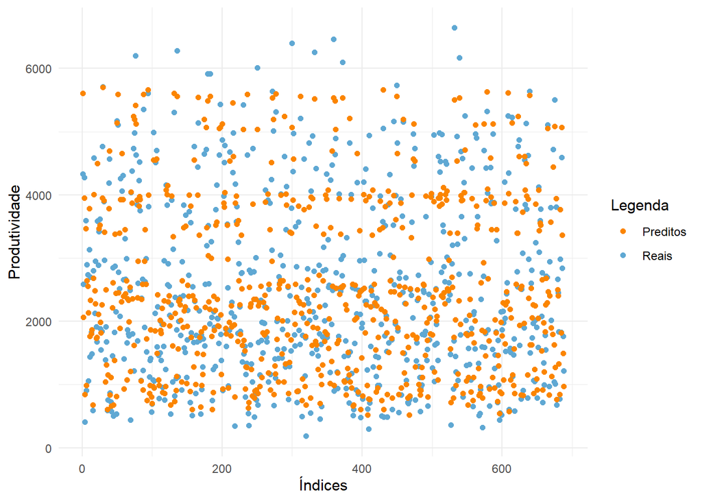

# Conclusão

De acordo com a análise de regressão, as principais variáveis que influenciam na produtividade da soja neste banco de dados são o tipo de terras e ambiente, o espaçamento entre linhas, a temperatura máxima durante o período de crescimento, o pH do solo e o teor de matéria orgânica. Além disso, práticas agrícolas como a escolha da cultura anterior e a quantidade de adubação com fósforo e nitrogênio também mostraram impacto significativo.

A análise diagnóstica do modelo identificou alguns pontos influentes e de alavancagem, mas estes não comprometeram significativamente a qualidade do ajuste. A verificação das suposições do modelo mostrou que a maioria foi atendida, exceto pela homoscedasticidade dos erros, indicando a presença de heteroscedasticidade. Isso sugere que este não é o melhor modelo, mas ainda oferece insights valiosos sobre os fatores que afetam a produtividade da soja.

# Trabalhos futuros

- Modelar a variância
- Remover pelo menos uma safra, em locais que foi realizado os ensaios em mais de um ano, para assim, evitar possível dependência temporal.
- Usar todos os blocos invés da média deles
- Pensar em uma forma de definir todos os dias de plantio
- Usar as coordenadas geográficas dos local como variáveis